## Run 1

- 8 verbs (4 positive, 4 negative) and 8 properties (4 positive, 4 negative) randomly paired up such that there are 2 items of each positive/negative verb/property combination
- between subjects conditions (prior, positive, negative), each of 10 subjects in each condition sees all 8 items

```r
process_condition_1 <- function(condition) {

  read_csv(sprintf("run 1/results_%s.csv", condition)) %>%
    select(HITId, starts_with("Input"), starts_with("Answer")) %>%
    rename_(.dots = setNames(names(.),
                             gsub("^.*\\.(.*)$", "\\1", names(.)))) %>%
    gather(key, value, starts_with("prompt"), starts_with("code"),
           starts_with("response")) %>%
    separate(key, c("type", "trial"), sep = "_") %>%
    spread(type, value) %>%
    separate(code, c("verb_valence", "property_valence"), sep = ";") %>%
    mutate(response = as.numeric(response),
           trial = as.numeric(trial),
           condition = condition,
           property = sub(".*How likely is someone being (.*) to .* people\\?",
                          "\\1", prompt),
           verb = sub(".*How likely is someone being .* to (.*) people\\?",
                      "\\1", prompt),
           item = paste(verb, property, sep = " + "),
           verb_valence = sub("verb_(.*)", "\\1", verb_valence),
           property_valence = sub("property_(.*)", "\\1", property_valence))

}
conditions_1 <- c("prior", "positive", "negative")
results_1 <- map_df(conditions_1, process_condition_1)
results_1
```

| HITId | list | comments | country | english | trial | verb_valence | property_valence | prompt | response | condition | property | verb | item |
| --- | --- | --- | --- | --- | --- | --- | --- | --- | --- | --- | --- | --- | --- |
| 307FVKVSYRFKD7O2TJDWLJWWYSP47U | 6 | {} | USA | yes | 1 | positive | negative | How likely is someone being greedy to amuse people? | 2 | prior | greedy | amuse | amuse + greedy |
| 307FVKVSYRFKD7O2TJDWLJWWYSP47U | 6 | {} | USA | yes | 2 | negative | positive | How likely is someone being courageous to bother people? | 1 | prior | courageous | bother | bother + courageous |
| 307FVKVSYRFKD7O2TJDWLJWWYSP47U | 6 | {} | USA | yes | 3 | negative | positive | How likely is someone being smart to upset people? | 4 | prior | smart | upset | upset + smart |
| 307FVKVSYRFKD7O2TJDWLJWWYSP47U | 6 | {} | USA | yes | 4 | positive | negative | How likely is someone being stupid to comfort people? | 3 | prior | stupid | comfort | comfort + stupid |
| 307FVKVSYRFKD7O2TJDWLJWWYSP47U | 6 | {} | USA | yes | 5 | positive | positive | How likely is someone being talented to delight people? | 5 | prior | talented | delight | delight + talented |
| 307FVKVSYRFKD7O2TJDWLJWWYSP47U | 6 | {} | USA | yes | 6 | negative | negative | How likely is someone being rude to worry people? | 3 | prior | rude | worry | worry + rude |
| 307FVKVSYRFKD7O2TJDWLJWWYSP47U | 6 | {} | USA | yes | 7 | negative | negative | How likely is someone being jealous to annoy people? | 4 | prior | jealous | annoy | annoy + jealous |
| 307FVKVSYRFKD7O2TJDWLJWWYSP47U | 6 | {} | USA | yes | 8 | positive | positive | How likely is someone being playful to inspire people? | 5 | prior | playful | inspire | inspire + playful |
| 33KMQD9OFJEHWU6LVHB3OVG6PUF77H | 10 | thx | USA | yes | 1 | negative | positive | How likely is someone being smart to upset people? | 3 | prior | smart | upset | upset + smart |
| 33KMQD9OFJEHWU6LVHB3OVG6PUF77H | 10 | thx | USA | yes | 2 | positive | negative | How likely is someone being greedy to amuse people? | 2 | prior | greedy | amuse | amuse + greedy |

[output cut: 230 more lines]

```r
results_summary_1 <- results_1 %>%
  group_by(condition, verb_valence, property_valence) %>%
  summarise(response_mean = mean(response, na.rm = TRUE),
            response_se = sem(response, na.rm = TRUE)) %>%
  ungroup() %>%
  mutate(condition = as_factor(condition))
results_summary_1
```

| condition | verb_valence | property_valence | response_mean | response_se |
| --- | --- | --- | --- | --- |
| negative | negative | negative | 3.90 | 0.1905670 |
| negative | negative | positive | 1.95 | 0.2457534 |
| negative | positive | negative | 1.75 | 0.2161262 |
| negative | positive | positive | 3.25 | 0.3151858 |
| positive | negative | negative | 2.95 | 0.4004931 |
| positive | negative | positive | 2.20 | 0.3292735 |
| positive | positive | negative | 1.70 | 0.2625783 |
| positive | positive | positive | 3.85 | 0.2741014 |
| prior | negative | negative | 3.00 | 0.3324550 |
| prior | negative | positive | 1.85 | 0.2325488 |

[output cut: 2 more lines]

```r
items_1 <- results_1 %>%
  filter(condition == "prior") %>%
  distinct(verb_valence, property_valence, verb, property) %>%
  group_by(verb_valence, property_valence) %>%
  summarise(verbs = paste(verb, collapse = ", "),
            properties = paste(property, collapse = ", "))
```

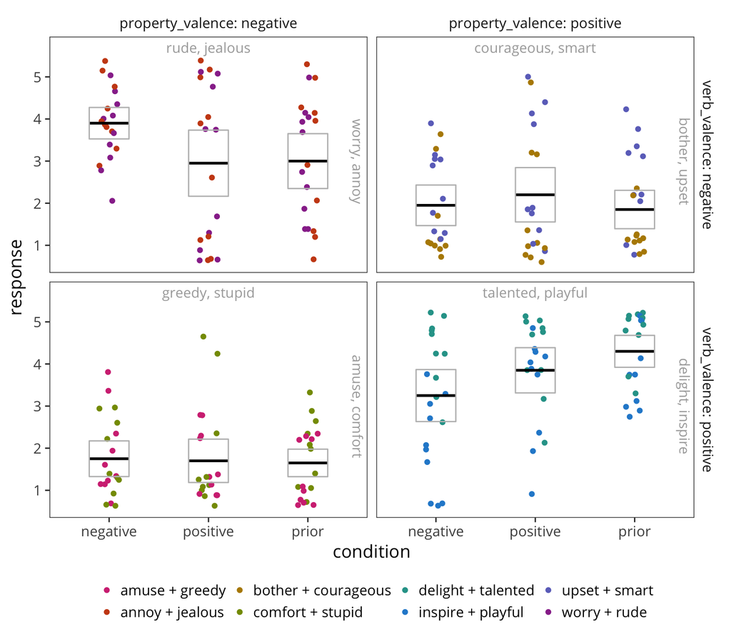

```r
ggplot(results_1, aes(x = condition, y = response, colour = item)) +
  facet_grid(verb_valence ~ property_valence, labeller = label_both) +
  geom_jitter(width = 0.1) +
  geom_segment(aes(y = response_mean, yend = response_mean,
                   x = as.numeric(condition) - 0.2,
                   xend = as.numeric(condition) + 0.2),
               data = results_summary_1, size = 1, colour = "black") +
  geom_rect(aes(xmin = as.numeric(condition) - 0.2,
                xmax = as.numeric(condition) + 0.2,
                ymin = response_mean + response_se * 1.96,
                ymax = response_mean - response_se * 1.96),
            colour = "grey", alpha = 0,
            data = results_summary_1, inherit.aes = FALSE) +
  geom_text(aes(label = properties), x = 2, y = 5.7, colour = "dark grey",
            family = "Open Sans", data = items_1) +
  geom_text(aes(label = verbs), x = 3.5, y = 3, colour = "dark grey",
            angle = -90, family = "Open Sans", data = items_1) +
  expand_limits(y = 5.7) +
  scale_colour_solarized(name = "") +
  theme(legend.position = "bottom")
```

## Run 2

- each combination of verb and property is an item (64 total)
- within subjects, each of 16 subjects sees 12 items, 4 from each condition

```r
results_2 <- read_csv("run 2/results_combined.csv") %>%
  select(HITId, starts_with("Input"), starts_with("Answer")) %>%
  rename_(.dots = setNames(names(.),
                           gsub("^.*\\.(.*)$", "\\1", names(.)))) %>%
  gather(key, value, starts_with("prompt"), starts_with("code"),
         starts_with("response")) %>%
  separate(key, c("type", "trial"), sep = "_") %>%
  spread(type, value) %>%
  mutate(response = as.numeric(response),
         trial = as.numeric(trial),
         property = sub(".*How likely is someone being (.*) to .* people\\?",
                        "\\1", prompt),
         verb = sub(".*How likely is someone being .* to (.*) people\\?",
                    "\\1", prompt),
         code_values = map(code, decode),
         condition = map_chr(code_values, ~.x[["condition"]]),
         verb_valence = map_chr(code_values, ~.x[["verb_valence"]]),
         property_valence = map_chr(code_values,
                                    ~.x[["property_valence"]])) %>%
  select(-code_values)
results_2
```

| HITId | list | comments | country | english | trial | code | prompt | response | property | verb | condition | verb_valence | property_valence |
| --- | --- | --- | --- | --- | --- | --- | --- | --- | --- | --- | --- | --- | --- |
| 308KJXFUJR6MDU1QFNQO3IAEF3KTAM | 16 | Interesting! | USA | yes | 1 | condition=positive,verb_valence=negative,property_valence=positive | Sarah tells you: "It annoys me that Jessica is courageous". How likely is someone being courageous to annoy people? | 1 | courageous | annoy | positive | negative | positive |
| 308KJXFUJR6MDU1QFNQO3IAEF3KTAM | 16 | Interesting! | USA | yes | 10 | condition=negative,verb_valence=positive,property_valence=positive | Jennifer tells you: "It doesn't inspire me that Jessica is talented". How likely is someone being talented to inspire people? | 5 | talented | inspire | negative | positive | positive |
| 308KJXFUJR6MDU1QFNQO3IAEF3KTAM | 16 | Interesting! | USA | yes | 11 | condition=prior,verb_valence=positive,property_valence=positive | How likely is someone being smart to comfort people? | 4 | smart | comfort | prior | positive | positive |
| 308KJXFUJR6MDU1QFNQO3IAEF3KTAM | 16 | Interesting! | USA | yes | 12 | condition=negative,verb_valence=negative,property_valence=negative | Melissa tells you: "It doesn't bother me that Nicole is greedy". How likely is someone being greedy to bother people? | 5 | greedy | bother | negative | negative | negative |
| 308KJXFUJR6MDU1QFNQO3IAEF3KTAM | 16 | Interesting! | USA | yes | 2 | condition=prior,verb_valence=positive,property_valence=negative | How likely is someone being jealous to inspire people? | 1 | jealous | inspire | prior | positive | negative |
| 308KJXFUJR6MDU1QFNQO3IAEF3KTAM | 16 | Interesting! | USA | yes | 3 | condition=prior,verb_valence=negative,property_valence=positive | How likely is someone being smart to annoy people? | 4 | smart | annoy | prior | negative | positive |
| 308KJXFUJR6MDU1QFNQO3IAEF3KTAM | 16 | Interesting! | USA | yes | 4 | condition=prior,verb_valence=negative,property_valence=negative | How likely is someone being stupid to worry people? | 5 | stupid | worry | prior | negative | negative |
| 308KJXFUJR6MDU1QFNQO3IAEF3KTAM | 16 | Interesting! | USA | yes | 5 | condition=negative,verb_valence=positive,property_valence=negative | Amanda tells you: "It doesn't inspire me that Nicole is stupid". How likely is someone being stupid to inspire people? | 1 | stupid | inspire | negative | positive | negative |
| 308KJXFUJR6MDU1QFNQO3IAEF3KTAM | 16 | Interesting! | USA | yes | 6 | condition=negative,verb_valence=negative,property_valence=positive | Stephanie tells you: "It doesn't annoy me that Nicole is courageous". How likely is someone being courageous to annoy people? | 1 | courageous | annoy | negative | negative | positive |
| 308KJXFUJR6MDU1QFNQO3IAEF3KTAM | 16 | Interesting! | USA | yes | 7 | condition=positive,verb_valence=positive,property_valence=negative | Jennifer tells you: "It inspires me that Nicole is stupid". How likely is someone being stupid to inspire people? | 1 | stupid | inspire | positive | positive | negative |

[output cut: 182 more lines]

```r
results_summary_2 <- results_2 %>%
  group_by(condition, verb_valence, property_valence) %>%
  summarise(response_mean = mean(response, na.rm = TRUE),
            response_se = sem(response, na.rm = TRUE)) %>%
  ungroup() %>%
  mutate(condition = as_factor(condition))
results_summary_2
```

| condition | verb_valence | property_valence | response_mean | response_se |
| --- | --- | --- | --- | --- |
| negative | negative | negative | 3.312500 | 0.3502231 |
| negative | negative | positive | 2.437500 | 0.3158157 |
| negative | positive | negative | 1.875000 | 0.3010399 |
| negative | positive | positive | 2.937500 | 0.2953635 |
| positive | negative | negative | 2.875000 | 0.3859512 |
| positive | negative | positive | 2.125000 | 0.3400368 |
| positive | positive | negative | 2.312500 | 0.3619248 |
| positive | positive | positive | 3.437500 | 0.3287445 |
| prior | negative | negative | 2.857143 | 0.3758820 |
| prior | negative | positive | 2.125000 | 0.3010399 |

[output cut: 2 more lines]

```r
items_2 <- results_2 %>%
  filter(condition == "prior") %>%
  distinct(verb_valence, property_valence, verb, property) %>%
  group_by(verb_valence, property_valence) %>%
  summarise(verbs = paste(sort(unique(verb)), collapse = ", "),
            properties = paste(sort(unique(property)), collapse = ", "))
```

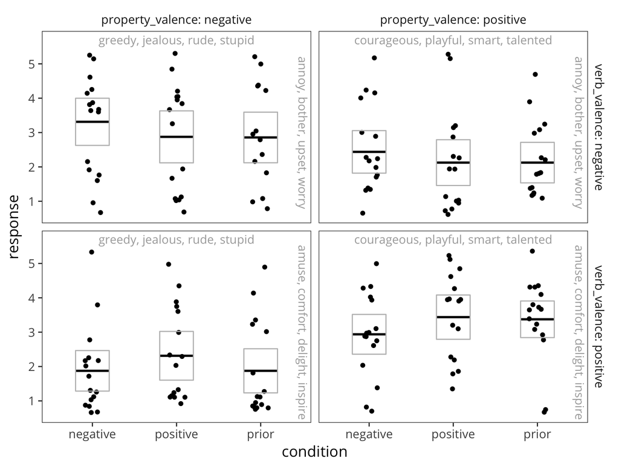

```r
ggplot(results_2, aes(x = condition, y = response)) +
  facet_grid(verb_valence ~ property_valence, labeller = label_both) +
  geom_jitter(width = 0.1) +
  geom_segment(aes(y = response_mean, yend = response_mean,
                   x = as.numeric(condition) - 0.2,
                   xend = as.numeric(condition) + 0.2),
               data = results_summary_2, size = 1, colour = "black") +
  geom_rect(aes(xmin = as.numeric(condition) - 0.2,
                xmax = as.numeric(condition) + 0.2,
                ymin = response_mean + response_se * 1.96,
                ymax = response_mean - response_se * 1.96),
            colour = "grey", alpha = 0,
            data = results_summary_2, inherit.aes = FALSE) +
  geom_text(aes(label = properties), x = 2, y = 5.7, colour = "dark grey",
            family = "Open Sans", data = items_2) +
  geom_text(aes(label = verbs), x = 3.5, y = 3, colour = "dark grey",
            angle = -90, family = "Open Sans", data = items_2) +
  expand_limits(y = 5.7)
```

## Run 3

- 8 verbs (4 positive, 4 negative) and 8 properties (4 positive, 4 negative) manually paired up such that they subjectively fit well and there are 4 positive/positive items and 4 negative/negative items
- 6 filler items (3 high likelihood, 3 low likelihood)
- between subjects conditions (prior, positive, negative), each of 20 subjects in each condition sees all 8 items and all 6 fillers

```r
process_condition_3 <- function(condition) {

  read_csv(sprintf("run 3/results_%s.csv", condition)) %>%
    select(HITId, starts_with("Input"), starts_with("Answer")) %>%
    rename_(.dots = setNames(names(.),
                             gsub("^.*\\.(.*)$", "\\1", names(.)))) %>%
    gather(key, value, starts_with("prompt"), starts_with("code"),
           starts_with("response")) %>%
    separate(key, c("type", "trial"), sep = "_") %>%
    spread(type, value) %>%
    mutate(response = as.numeric(response),
           trial = as.numeric(trial),
           condition = condition,
           info = map(code, decode),
           type = map_chr(info,
                          ~ifelse(all(names(.x) == "filler_value"), "filler",
                                  "item")))
}
conditions_3 <- c("prior", "positive", "negative")
results_3 <- map_df(conditions_3, process_condition_3) %>%
  split(.$type)
results_filler_3 <- results_3$filler %>%
  mutate(filler_value = map_chr(info, ~.x[["filler_value"]]),
         correct = (filler_value == "high" & response >= 4) |
           (filler_value == "low" & response <= 2))
filler_filter_3 <- results_filler_3 %>%
  group_by(HITId) %>%
  summarise(n_correct = sum(correct, na.rm = TRUE)) %>%
  filter(n_correct >= 5)
results_item_3 <- results_3$item %>%
  filter(HITId %in% filler_filter_3$HITId) %>%
  mutate(verb_valence = map_chr(info, ~.x[["verb_valence"]]),
         property_valence = map_chr(info, ~.x[["property_valence"]]),
         item = sub(".*How likely is someone being (.*) to (.*) people\\?",
                    "\\1 \\+ \\2", prompt))
results_item_3
```

| HITId | list | comments | country | english | trial | code | prompt | response | condition | info | type | verb_valence | property_valence | item |
| --- | --- | --- | --- | --- | --- | --- | --- | --- | --- | --- | --- | --- | --- | --- |
| 351S7I5UG9WZJAZACXHPNI75GMVNJQ | 2 | {} | USA | yes | 1 | verb_valence=negative,property_valence=negative | How likely is someone being rude to upset people? | 4 | prior |  | item | negative | negative | rude + upset |
| 351S7I5UG9WZJAZACXHPNI75GMVNJQ | 2 | {} | USA | yes | 2 | verb_valence=negative,property_valence=negative | How likely is someone being stupid to annoy people? | 2 | prior |  | item | negative | negative | stupid + annoy |
| 351S7I5UG9WZJAZACXHPNI75GMVNJQ | 2 | {} | USA | yes | 3 | verb_valence=positive,property_valence=positive | How likely is someone being courageous to comfort people? | 4 | prior |  | item | positive | positive | courageous + comfort |
| 351S7I5UG9WZJAZACXHPNI75GMVNJQ | 2 | {} | USA | yes | 4 | verb_valence=positive,property_valence=positive | How likely is someone being playful to amuse people? | 5 | prior |  | item | positive | positive | playful + amuse |
| 351S7I5UG9WZJAZACXHPNI75GMVNJQ | 2 | {} | USA | yes | 5 | verb_valence=negative,property_valence=negative | How likely is someone being greedy to bother people? | 2 | prior |  | item | negative | negative | greedy + bother |
| 351S7I5UG9WZJAZACXHPNI75GMVNJQ | 2 | {} | USA | yes | 6 | verb_valence=positive,property_valence=positive | How likely is someone being smart to inspire people? | 2 | prior |  | item | positive | positive | smart + inspire |
| 351S7I5UG9WZJAZACXHPNI75GMVNJQ | 2 | {} | USA | yes | 7 | verb_valence=negative,property_valence=negative | How likely is someone being jealous to anger people? | 1 | prior |  | item | negative | negative | jealous + anger |
| 351S7I5UG9WZJAZACXHPNI75GMVNJQ | 2 | {} | USA | yes | 8 | verb_valence=positive,property_valence=positive | How likely is someone being talented to delight people? | 3 | prior |  | item | positive | positive | talented + delight |
| 39XCQ6V3KY4J5QEXOEREKX2E3VC56D | 20 | {} | USA | yes | 1 | verb_valence=negative,property_valence=negative | How likely is someone being rude to upset people? | 2 | prior |  | item | negative | negative | rude + upset |
| 39XCQ6V3KY4J5QEXOEREKX2E3VC56D | 20 | {} | USA | yes | 2 | verb_valence=negative,property_valence=negative | How likely is someone being stupid to annoy people? | 2 | prior |  | item | negative | negative | stupid + annoy |

[output cut: 382 more lines]

```r
results_summary_3 <- results_item_3 %>%
  group_by(condition, verb_valence, property_valence) %>%
  summarise(response_mean = mean(response, na.rm = TRUE),
            response_se = sem(response, na.rm = TRUE)) %>%
  ungroup() %>%
  mutate(condition = as_factor(condition))
results_summary_3
```

| condition | verb_valence | property_valence | response_mean | response_se |
| --- | --- | --- | --- | --- |
| negative | negative | negative | 3.485294 | 0.1669494 |
| negative | positive | positive | 3.492537 | 0.1638704 |
| positive | negative | negative | 4.016667 | 0.1672166 |
| positive | positive | positive | 3.750000 | 0.1378302 |
| prior | negative | negative | 2.985075 | 0.1640351 |
| prior | positive | positive | 3.647059 | 0.1217460 |

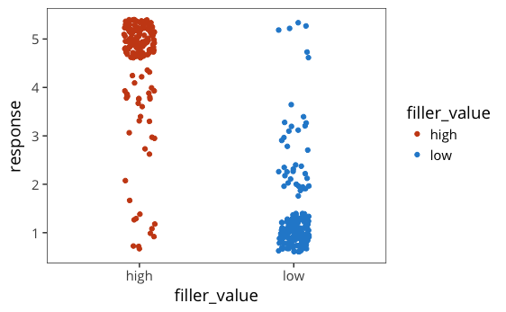

```r
ggplot(results_filler_3,
       aes(x = filler_value, y = response, colour = filler_value)) +
  geom_jitter(width = 0.1) +
  scale_colour_solarized()
```

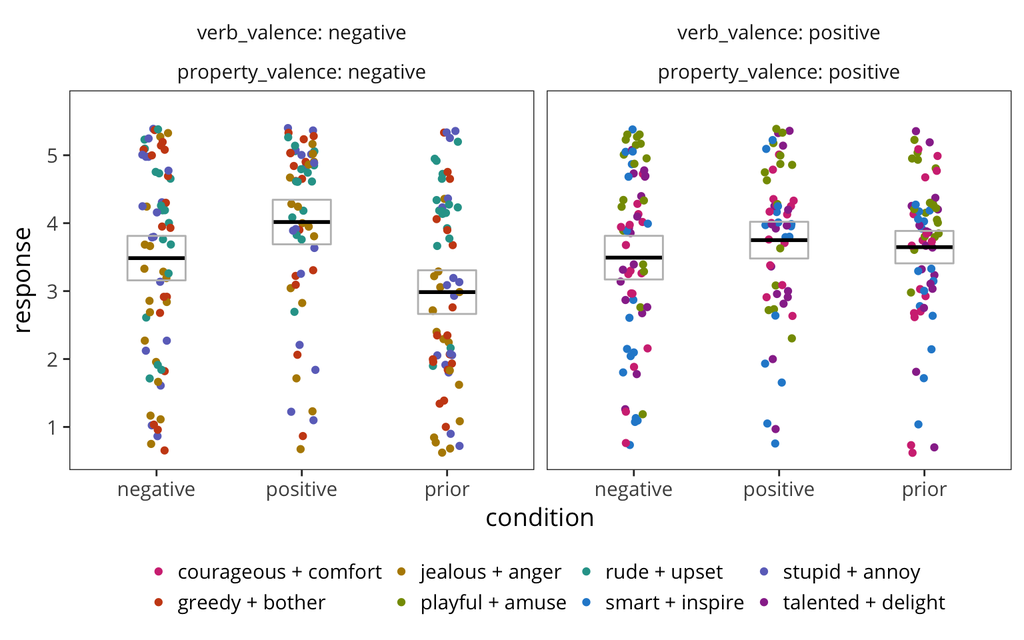

```r
ggplot(results_item_3, aes(x = condition, y = response, colour = item)) +
  facet_wrap(~verb_valence + property_valence,
             labeller = label_both) +
  geom_jitter(width = 0.1) +
  geom_segment(aes(y = response_mean, yend = response_mean,
                   x = as.numeric(condition) - 0.2,
                   xend = as.numeric(condition) + 0.2),
               data = results_summary_3, size = 1, colour = "black") +
  geom_rect(aes(xmin = as.numeric(condition) - 0.2,
                xmax = as.numeric(condition) + 0.2,
                ymin = response_mean + response_se * 1.96,
                ymax = response_mean - response_se * 1.96),
            colour = "grey", alpha = 0,
            data = results_summary_3, inherit.aes = FALSE) +
  expand_limits(y = 5.7) +
  scale_colour_solarized(name = "") +
  theme(legend.position = "bottom")
```

## Run 4

- 24 verbs (12 positive, 12 negative) and 24 properties (12 positive, 12 negative) manually paired up such that they subjectively fit well and there are 12 positive/positive items and 12 negative/negative items
- 6 filler items, each with a high likelihood match and a low likelihood match (12 fillers total)
- between subjects conditions (prior, positive, negative), each of 30 subjects in each condition sees all 24 items and all 12 fillers
- participants only included if country is USA, native language is English, and number of fillers correct (rated 4 or 5 for high likelihood, rated 1 or 2 for low likelihood) is at least 10

| HITId | list | comments | country | english | trial | code | prompt | response | condition | info | type | verb_valence | property_valence | item |
| --- | --- | --- | --- | --- | --- | --- | --- | --- | --- | --- | --- | --- | --- | --- |
| 304QEQWKZPKAZPY0R47WK2SFB5M0O9 | 23 | My kind of academic study! Thanks. | USA | yes | 10 | verb_valence=negative,property_valence=negative | How likely is someone being vengeful to upset people? | 5 | prior |  | item | negative | negative | vengeful + upset |
| 304QEQWKZPKAZPY0R47WK2SFB5M0O9 | 23 | My kind of academic study! Thanks. | USA | yes | 11 | verb_valence=negative,property_valence=negative | How likely is someone being violent to hurt people? | 5 | prior |  | item | negative | negative | violent + hurt |
| 304QEQWKZPKAZPY0R47WK2SFB5M0O9 | 23 | My kind of academic study! Thanks. | USA | yes | 12 | verb_valence=positive,property_valence=positive | How likely is someone being funny to entertain people? | 5 | prior |  | item | positive | positive | funny + entertain |
| 304QEQWKZPKAZPY0R47WK2SFB5M0O9 | 23 | My kind of academic study! Thanks. | USA | yes | 14 | verb_valence=positive,property_valence=positive | How likely is someone being enthusiastic to delight people? | 3 | prior |  | item | positive | positive | enthusiastic + delight |
| 304QEQWKZPKAZPY0R47WK2SFB5M0O9 | 23 | My kind of academic study! Thanks. | USA | yes | 16 | verb_valence=negative,property_valence=negative | How likely is someone being inconsiderate to disappoint people? | 4 | prior |  | item | negative | negative | inconsiderate + disappoint |
| 304QEQWKZPKAZPY0R47WK2SFB5M0O9 | 23 | My kind of academic study! Thanks. | USA | yes | 17 | verb_valence=negative,property_valence=negative | How likely is someone being unfriendly to depress people? | 3 | prior |  | item | negative | negative | unfriendly + depress |
| 304QEQWKZPKAZPY0R47WK2SFB5M0O9 | 23 | My kind of academic study! Thanks. | USA | yes | 19 | verb_valence=positive,property_valence=positive | How likely is someone being faithful to encourage people? | 3 | prior |  | item | positive | positive | faithful + encourage |
| 304QEQWKZPKAZPY0R47WK2SFB5M0O9 | 23 | My kind of academic study! Thanks. | USA | yes | 20 | verb_valence=positive,property_valence=positive | How likely is someone being cheerful to charm people? | 4 | prior |  | item | positive | positive | cheerful + charm |
| 304QEQWKZPKAZPY0R47WK2SFB5M0O9 | 23 | My kind of academic study! Thanks. | USA | yes | 22 | verb_valence=positive,property_valence=positive | How likely is someone being playful to amuse people? | 5 | prior |  | item | positive | positive | playful + amuse |
| 304QEQWKZPKAZPY0R47WK2SFB5M0O9 | 23 | My kind of academic study! Thanks. | USA | yes | 23 | verb_valence=positive,property_valence=positive | How likely is someone being honest to relieve people? | 3 | prior |  | item | positive | positive | honest + relieve |

[output cut: 990 more lines]

```r
results_summary_4 <- results_item_4 %>%
  group_by(condition, verb_valence, property_valence) %>%
  summarise(response_mean = mean(response, na.rm = TRUE),
            response_se = sem(response, na.rm = TRUE)) %>%
  ungroup() %>%
  mutate(condition = as_factor(condition))
results_summary_4
```

| condition | verb_valence | property_valence | response_mean | response_se |
| --- | --- | --- | --- | --- |
| negative | negative | negative | 3.626812 | 0.07496698 |
| negative | positive | positive | 3.503623 | 0.06297378 |
| positive | negative | negative | 3.919732 | 0.06931313 |
| positive | positive | positive | 3.866667 | 0.05847053 |
| prior | negative | negative | 3.756173 | 0.06570061 |
| prior | positive | positive | 4.027864 | 0.04607023 |

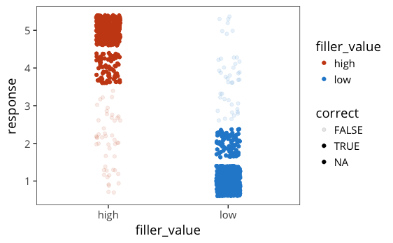

```r
ggplot(results_filler_4,
       aes(x = filler_value, y = response, colour = filler_value,
           alpha = correct)) +
  geom_jitter(width = 0.1) +
  scale_colour_solarized()
```

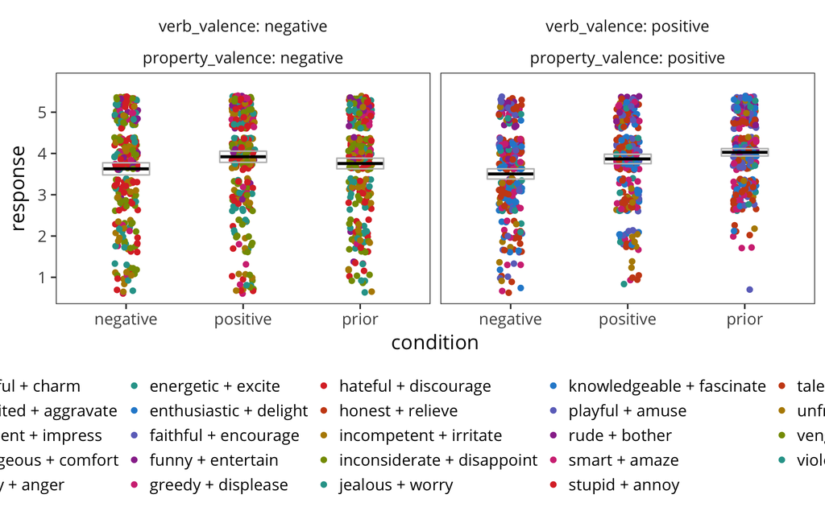

```r
ggplot(results_item_4, aes(x = condition, y = response, colour = item)) +
  facet_wrap(~verb_valence + property_valence,
             labeller = label_both) +
  geom_jitter(width = 0.1) +
  geom_segment(aes(y = response_mean, yend = response_mean,
                   x = as.numeric(condition) - 0.2,
                   xend = as.numeric(condition) + 0.2),
               data = results_summary_4, size = 1, colour = "black") +
  geom_rect(aes(xmin = as.numeric(condition) - 0.2,
                xmax = as.numeric(condition) + 0.2,
                ymin = response_mean + response_se * 1.96,
                ymax = response_mean - response_se * 1.96),
            colour = "grey", alpha = 0,
            data = results_summary_4, inherit.aes = FALSE) +
  expand_limits(y = 5.7) +
  scale_colour_solarized(name = "") +
  theme(legend.position = "bottom")
```

```r
results_item_4 %>%
  split(.$verb_valence) %>%
  map(~lm(response ~ condition, data = .x)) %>%
  map(summary)
```

```
$negative

Call:
lm(formula = response ~ condition, data = .x)

Residuals:
    Min      1Q  Median      3Q     Max
-2.9197 -0.7562  0.2438  1.0803  1.3732

Coefficients:
                  Estimate Std. Error t value Pr(>|t|)
(Intercept)        3.62681    0.07268  49.900  < 2e-16 ***
conditionpositive  0.29292    0.10079   2.906  0.00375 **
conditionprior     0.12936    0.09891   1.308  0.19124
---
Signif. codes:  0 ‘***’ 0.001 ‘**’ 0.01 ‘*’ 0.05 ‘.’ 0.1 ‘ ’ 1

Residual standard error: 1.207 on 896 degrees of freedom
  (1 observation deleted due to missingness)
Multiple R-squared:  0.00942,   Adjusted R-squared:  0.007209
F-statistic:  4.26 on 2 and 896 DF,  p-value: 0.0144


$positive

Call:
lm(formula = response ~ condition, data = .x)

Residuals:
    Min      1Q  Median      3Q     Max
-3.0279 -0.5036  0.1333  0.9721  1.4964

Coefficients:
                  Estimate Std. Error t value Pr(>|t|)
(Intercept)        3.50362    0.05788  60.534  < 2e-16 ***
conditionpositive  0.36304    0.08020   4.527 6.80e-06 ***
conditionprior     0.52424    0.07882   6.651 5.05e-11 ***
---
Signif. codes:  0 ‘***’ 0.001 ‘**’ 0.01 ‘*’ 0.05 ‘.’ 0.1 ‘ ’ 1

Residual standard error: 0.9615 on 896 degrees of freedom
  (1 observation deleted due to missingness)
Multiple R-squared:  0.04846,   Adjusted R-squared:  0.04634
F-statistic: 22.82 on 2 and 896 DF,  p-value: 2.16e-10
```

```r
results_item_4 %>%
  mutate(condition = fct_relevel(condition,
                                 c("prior", "positive", "negative")),
         scaled_response = scale(response)) %>%
  split(.$verb_valence) %>%
  map(~lmer(scaled_response ~ condition + (condition | HITId) + (condition | item),
            data = .x)) %>%
  map(summary)
```

```
$negative
Linear mixed model fit by REML ['lmerMod']
Formula: scaled_response ~ condition + (condition | HITId) + (condition |
    item)
   Data: .x

REML criterion at convergence: 2246

Scaled residuals:
    Min      1Q  Median      3Q     Max
-3.3765 -0.6131  0.1290  0.5934  2.7580

Random effects:
 Groups   Name              Variance Std.Dev. Corr
 HITId    (Intercept)       0.344451 0.5869
          conditionpositive 0.275227 0.5246   -0.20
          conditionnegative 0.372640 0.6104   -0.42  0.05
 item     (Intercept)       0.225797 0.4752
          conditionpositive 0.016299 0.1277    0.10
          conditionnegative 0.005807 0.0762    0.89 -0.36
 Residual                   0.557608 0.7467
Number of obs: 899, groups:  HITId, 75; item, 12

Fixed effects:
                  Estimate Std. Error t value
(Intercept)       -0.03244    0.18247  -0.178
conditionpositive  0.14947    0.19375   0.771
conditionnegative -0.11718    0.18745  -0.625

Correlation of Fixed Effects:
            (Intr) cndtnp
conditnpstv -0.395
conditnngtv -0.345  0.391
convergence code: 0
Model is nearly unidentifiable: large eigenvalue ratio
 - Rescale variables?


$positive
Linear mixed model fit by REML ['lmerMod']
```

[output cut: 19 more lines]

```
Number of obs: 899, groups:  HITId, 75; item, 12

Fixed effects:
                  Estimate Std. Error t value
(Intercept)         0.2132     0.1037   2.057
conditionpositive  -0.1456     0.1416  -1.028
conditionnegative  -0.4744     0.1419  -3.343

Correlation of Fixed Effects:
            (Intr) cndtnp
conditnpstv -0.233
conditnngtv -0.261  0.281
convergence code: 0
unable to evaluate scaled gradient
Model failed to converge: degenerate  Hessian with 2 negative eigenvalues
```